# Effects of Class Size on Math Performance in Tennessee

### Team ID: Team 6

#### NAME: Connor Rosenberg

#### NAME: Rongkui Han

#### NAME: Yuqing Yang

#### NAME: Nassim Ali-Chaouche

## 1.0 Introduction

### 1.1 Background

The Student/Teacher Achievement Ratio (STAR) was a four-year longitudinal class-size study funded by the Tennessee General Assembly and conducted by the State Department of Education. Over 7,000 students from kindergarten to 3rd grade in 79 schools were randomly assigned into one of three interventions: small class (13 to 17 students per teacher), regular class (22 to 25 students per teacher), and regular-with-aide class (22 to 25 students with a full-time teacher’s aide). The interventions were initiated as the students entered school in kindergarten and continued through third grade.

Besides following standard procedures that ensured confidentiality and ethics in human subjects’ research, Project STAR also highlights the important features of:

1. *Each school included in the study had to have a large enough student body to form as least one of each of the three class types.*
2. *Students and teachers were randomly assigned to their class type.*

Project STAR is an example of **stratified randomized design**, where experimental units are grouped together according to certain pre-treatment characteristics into strata. Within each stratum, a completely randomized experiment is conducted. In the case that there exist population structures that associate or covary with the experimental outcome, stratified randomized experiments generally are more informative than completely randomized experiments (Suresh K., 2011). The goal of a stratified study is usually not to identify treatment effects within a single stratum, but rather treatment effects across all strata.

Because it is reasonable to expect systemic differences in educational outcome across schools, due to reasons such as demographics, school could be a confounding variable and influence the ooutcome of the Project STAR research. Therefore, each school should be viewed as a stratum in analyzing Project STAR data.

To expand on previous findings, teachers, rather than individual student, will be used as experimental units. The adjustment of experimental unit will facilitate the making of a causal statement as to the effect of class size on educational outcome, because the teacher experimental units more convincingly satisfy the stable unit treatment value assumption (SUTVA) and independence assumptions necessary for causal inferences. The detail of these assumtions will be dissected in the discussion section.

### 1.2 Questions of Interest

Our questions of interest are as follows:

1. Is there a significant difference in a first-grade teacher’s teaching performance in math across the three different class sizes?
2. Are teacher’s performances relatively stable between different schools? That is, does the school itself affect class average math scores?
3. Does our ANOVA model fit well with the data? In other words, are the analysis of variance assumptions satisfied?
4. Can we draw causal conclusion that class sizes affect the class average math scores of first-grade teachers?

## 2.0 Analysis Plan

### 2.1 Population and study design

A two-way ANOVA test is fitting for answering our questions of interest under the stratified randomized design. One factor in the ANOVA model will be class size, whose main effect is of primary interest in this study. The other factor will be school ID, in order to control for and observe the stratum effect.

In oreder to treat teachers as the experimental units, we will use the *median* scaled 1st grade math score of all students under each teacher for our analysis. The median score of a class truthfully reflects the class’ performance. In additon, the median is usually a more robust summary statistic than the mean, because it is less affected by outliers.

### 2.2 Statistical Analysis

#### 2.2.1 Descriptive Analysis

We will check - Completedness and balance of each stratum; - Variation of response variable, scaled 1st grade math score, across class types; - Variation of response variable across strata;

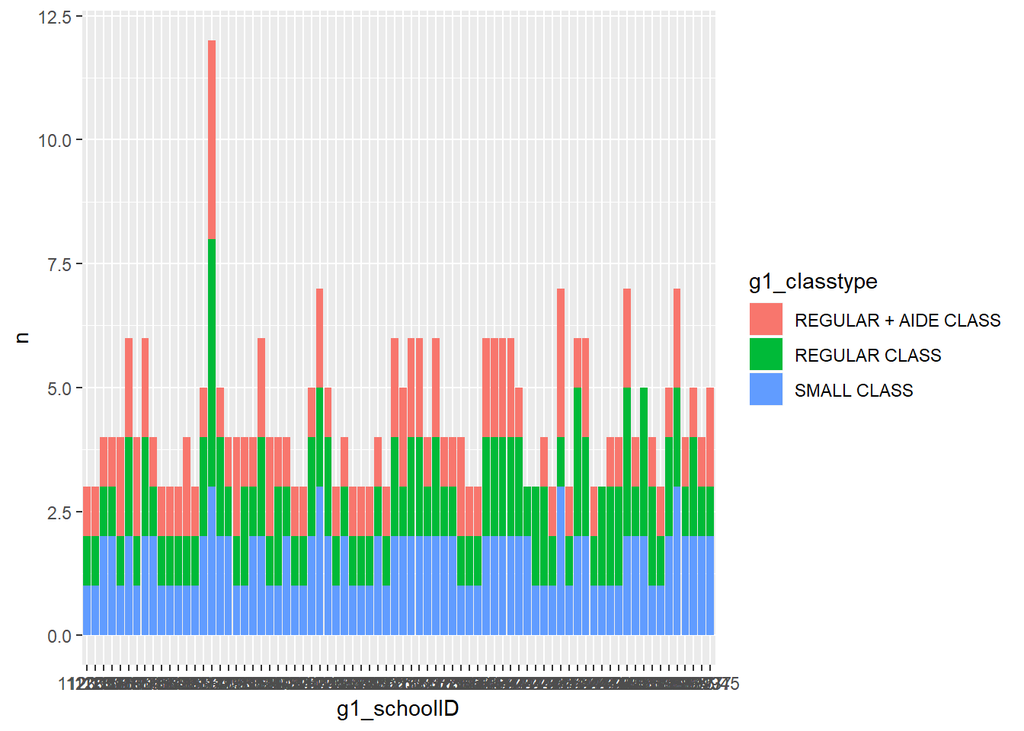

#### 2.2.2 Main Analysis

- $μ_{..}$ represents the overall classroom median score across all treatment levels.
- $τ_i$ represents the effect of each class size on the overall median math score.
- $β_j$ represents the effect of each school on the overall median math score.

Our model is appropriate to answer the questions of interest because it captures the effect of each treatment on the class’ median performance while controlling for other external factors by blocking by school id.

[interactive chart not shown]

Because of this high variability in median classroom performance between schools, blocking by school ID in our model helps to extract the true effect of the class size treatment on the classroom median math performance.

## 3.0 Results

### 3.2 Main Analysis

Model ANOVA Table

|  | Df | Sum Sq | Mean Sq | F value | Pr(>F) |
| --- | --- | --- | --- | --- | --- |
| g1_classtype | 2 | 10796.02 | 5398.01 | 17.25 | <.001 |
| g1_schoolID | 75 | 149258.51 | 1990.11 | 6.36 | <.001 |
| Residuals | 260 | 81345.30 | 312.87 | NA | NA |

### 3.3 Sensitivity analysis

#### 3.3.1 Normality

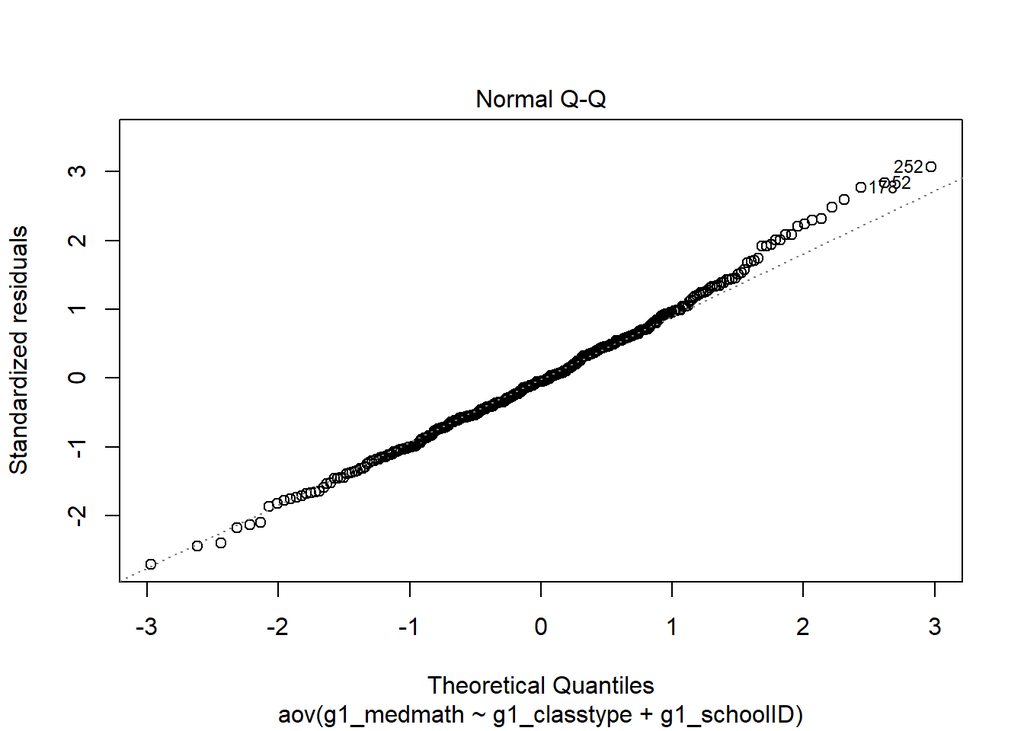

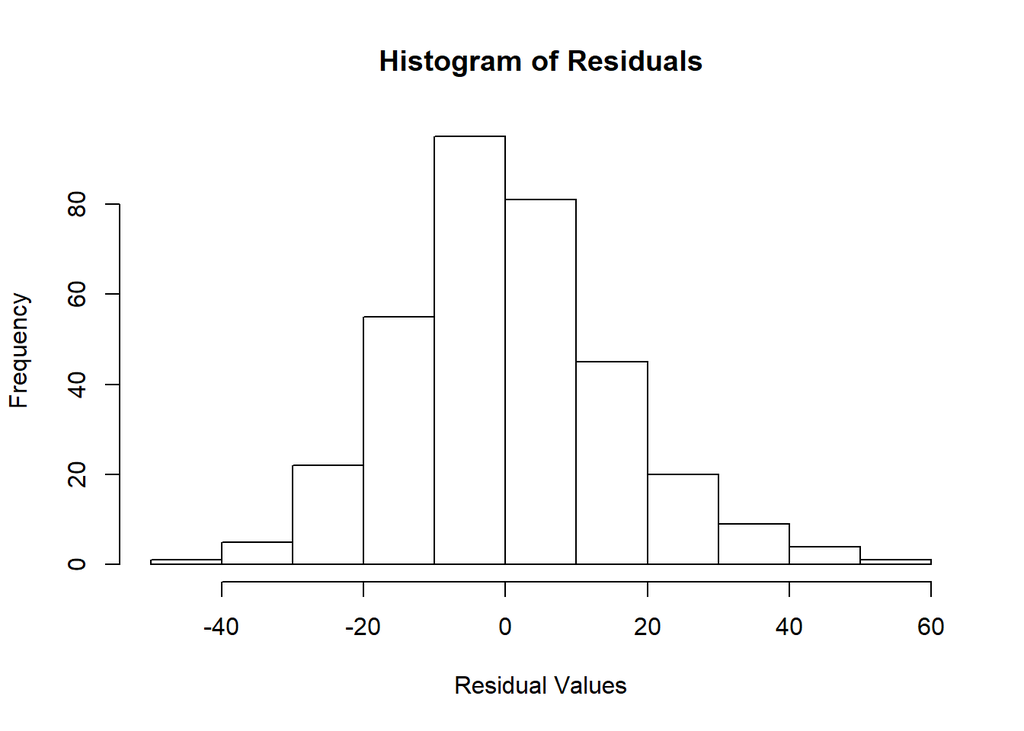

To visualize the distribution of the residuals, a histogram will be used:

From the histogram of the residuals, we can observe that the distribution of the residuals looks symmetric about the mean and bell-shaped, similar to what is seen from a normal distribution.

To further test for normality of the errors, a Shapiro-Wilk test will be used on the distribution of the residuals. A Shapiro-Wilk test is used to test whether a distribution of data follows a normal distribution.

The hypotheses are as follows: $H_o$: The residuals are normally distributed. $H_a$: The residuals are not normally distributed.

Shapiro-Wilk Normality Test

| W Statistic | P-Value |
| --- | --- |
| 0.99 | 0.13 |

The p-value of 0.13 is greater than the significance level of 0.05, and thus we fail to reject the null hypothesis. Thus, there is no evidence that the distribution of the residuals does not follow a normal distribution.

#### 3.3.2 Equal Variances:

Residual vs Fitted Plot:

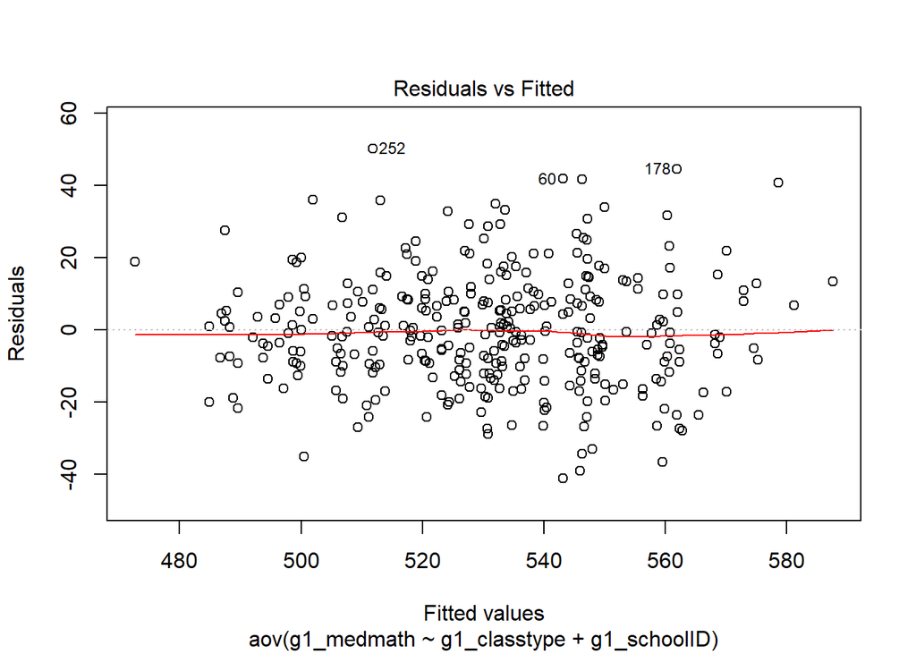

The residuals are evenly spread out along the x-axis, and thus it seems that the equal variance assumption is satisfied.

A Levene’s test will be used to further test the equal variance assumption for both variables.

The hypotheses are as follows: $H_o$: The variances are equal across the various groups. $H_a$: Not all variances are equal across groups.

Levene Test for Class Type Variable

| df | F Value | Pr(>F) |
| --- | --- | --- |
| 2, 335 | 0.34 | 0.71 |

Levene Test for School ID Variable

| df | F Value | Pr(>F) |
| --- | --- | --- |
| 75, 262 | 0.76 | 0.92 |

In the Levene’s test for both variables, both p-values are greater than the significance level of 0.05. Thus for each variable, there is no evidence that not all of the variances are equal across treatment groups. Thus, the equal variance assumption is satisfied.

#### 3.3.3 Independence:

This experiment is randomized in two ways and represents the best controlled environment to achieve independence of the results. First of all, teachers are randomly assigned to each class type: small, regular, and regular with aide. Second, every student is randomly assigned to each teacher. There is a possibility of the independence assumption not holding completely from the time of randomization to the time that the test scores were recorded. For instance, teachers may share materials, or parents may seek out tutoring for their child. However, given the randomized design of the experiment and the relatively large sample size, we may assume that the results are essentially independent.

#### 3.3.4 Outliers:

An outlier is defined as an observation whose studentized residual has a magnitude greater than three.

Outliers

| Number of Outliers | Observation Numbers |
| --- | --- |
| 1 | 252 |

There is only one outlier in the data, which is observation number 252. Thus, outliers do not pose a problem in our analysis.

## 4.0 Discussion

This analysis enables us to make causal statements regarding the effect of class size on teacher’s performance in math education. This is made possible by using teachers as experimental units, thus satisfying the SUTVA and independence assumptions necessary for causal inferences:

**SUTVA**: Definition: *The potential outcomes for any unit do not vary with the treatments assigned to other units, and, for each unit, there are no different forms or versions of each treatment level, which lead to different potential outcomes.*  
The experimental unit used in the analysis first satisfies the no-interference component of SUTVA – the assumption that the treatment applied to one unit does not affect the outcome for other units. On the basis of prior knowledge of school systems, it is realistic to assume that one teacher being assigned to a specific class size does not affect the teaching outcoome of another teacher. The second component of SUTVA requires that individuals receiving a specific treatment cannot receive different forms of that treatment. In our case, due to the strict randomization implemented in the experiment, the class taught by one teacher is by nature homogenous with a class taught by another.

**Independence Assumption**:  
Definition: *the assignment of treatment is independent of potential outcomes of experimental units.*  
This assumption is met in the experiment by using double randomization: One random assignment is that of teachers to classes. The second randomization is of students to classes/teachers. The design ensures that high/low performance teacher or students were not systematically enriched in any class-size treatments. In light of this, systematic effects can be interpreted as the effects of class size.

Therefore, our analysis concludes that smaller class size has a positive average causal effect on a teacher’s teaching outcome in math. This is different from the conclusion of Project I. SUTVA was not plausible when using individual students as experimental units. Interactions between students likely resulted in altered potential outcome of one student due to the treatment assigned to another, thus violating SUTVA. In that case, rejections of the null hypothesis would not necessarily be convincing evidence of effects of class size; it may simply indicate the presence of peer effects. In contrast, using teachers as experimental units does not rely on no-interference assumptions among students. This makes the results reported here credible evidence of causal class-size effects.

## 5.0 Reference

Suresh K. (2011). An overview of randomization techniques: An unbiased assessment of outcome in clinical research. Journal of human reproductive sciences, 4(1), 8–11. doi:10.4103/0974-1208.82352